# Proyecto Final: Parte 4

Rolando Fortanell Canedo Luis Eduardo Jiménez del Muro Diego Lozoya Morales Lenin Adair Quezada Gómez

2025-04-25

# Librerías

```r
suppressPackageStartupMessages(library(quantmod))
suppressPackageStartupMessages(library(lubridate))
suppressPackageStartupMessages(library(dplyr))
suppressPackageStartupMessages(library(fTrading))
suppressPackageStartupMessages(library(fGarch))
suppressPackageStartupMessages(library(forecast))
suppressPackageStartupMessages(library(bizdays))
suppressPackageStartupMessages(library(tidyr))
suppressPackageStartupMessages(library(rugarch))
suppressPackageStartupMessages(library(scales))
suppressPackageStartupMessages(library(ggplot2))
```

# Introducción

En este proyecto se estudiará el comportamiento del riesgo en el activo GCC a partir de sus rendimientos históricos, aplicando diferentes metodologías de estimación de volatilidad. El análisis comenzará evaluando distintas aproximaciones mediante medias móviles, para entender el comportamiento de la varianza a corto y mediano plazo. A partir de ahí, se ajustará un modelo EWMA, optimizando el parámetro de suavizamiento para capturar la persistencia de la volatilidad en el tiempo.

Adicionalmente, se modelará la dinámica de los rendimientos con un ARIMA, y se explorará la presencia de efectos ARCH, abriendo paso a la implementación de modelos GARCH de diferentes órdenes. La comparación de estas alternativas permitirá identificar cuál de ellas ofrece una mejor representación del riesgo de GCC, no solo a través de métricas estadísticas, sino también mediante una evaluación gráfica de las predicciones frente a los datos observados.

Este enfoque integral permitirá construir una visión sólida sobre la naturaleza de la volatilidad en el activo y su relevancia para la gestión de riesgos financieros.

# Datos

```r
clave <- "GCC.MX"
datos <- new.env()

getSymbols(clave, to="2025-04-25", env=datos)
```

```
## [1] "GCC.MX"
```

```r
precio <- datos[[clave]][,6]
rt <- na.omit(diff(log(precio)))
```

# Medias móviles

El primer modelo de varianza que se utiliza es la media movil. Este es un modelo que se utiliza para suavizar los datos y eliminar el ruido. La media movil se calcula tomando el promedio de los rendimientos al cuadrado en una ventana de tiempo determinada. En este caso la ventana de timepo posible a utilizar es de 5, 10, 20 y 40 días. Para decidir cual es la mejor opción, se calulan los errores RMSE, EAMP y ECPP, de la manera:

- **RMSE** Error cuadrático medio $\text{RMSE} = \frac{1}{H} \sqrt{\sum_{i=1}^{n} (R_i^2-\sigma_i^2)^2}$
- **EAMP** Error Absoluto Medio Proporcional $\text{EAMP} = \frac{1}{H} |R_i^2-\sigma^2_i|$
- **ECPP** Error cuadrático Promedio Proporcional $\text{ECPP} = \frac{1}{H} (\frac{ R_i^2-\sigma_1^2 }{\sigma_i^2})^2$

```r
rend_2 <- rt^2

var_5 <- SMA(rend_2, n=5+1)
var_10 <- SMA(rend_2, n=10+1)
var_20 <- SMA(rend_2, n=20+1)
var_40 <- SMA(rend_2, n=40+1)

RMSE <- tibble(
  "M=5"=sqrt(mean(na.omit(rend_2-var_5)^2)),
  "M=10"=sqrt(mean(na.omit(rend_2-var_10)^2)),
  "M=20"=sqrt(mean(na.omit(rend_2-var_20)^2)),
  "M=40"=sqrt(mean(na.omit(rend_2-var_40)^2))
)

EAMP <- tibble(
  "M=5"=mean(abs(na.omit(rend_2-var_5))),
  "M=10"=mean(abs(na.omit(rend_2-var_10))),
  "M=20"=mean(abs(na.omit(rend_2-var_20))),
  "M=40"=mean(abs(na.omit(rend_2-var_40)))
)

w <- merge.xts((na.omit(var_5-rend_2)/na.omit(rend_2))^2,
               (na.omit(var_10-rend_2)/na.omit(rend_2))^2,
               (na.omit(var_20-rend_2)/na.omit(rend_2))^2,
               (na.omit(var_40-rend_2)/na.omit(rend_2))^2)
w <- subset(w, w$SMA!="Inf")

ECPP <- sqrt(colMeans(na.omit(w)))

tabla_comparativa <- tibble(
  M = c("M=5", "M=10", "M=20", "M=40"),
  RMSE = unlist(RMSE),
  EAMP = unlist(EAMP),
  ECPP = unlist(ECPP)
)
knitr::kable(tabla_comparativa, caption = "Comparación de cada valor M", digits = 6)
```

Comparación de cada valor M

| M | RMSE | EAMP | ECPP |
| --- | --- | --- | --- |
| M=5 | 0.001865 | 0.000509 | NaN |
| M=10 | 0.001974 | 0.000559 | NaN |
| M=20 | 0.002048 | 0.000588 | NaN |
| M=40 | 0.002079 | 0.000602 | NaN |

En este caso se elige utilizar m=5 ya que al comparar los errores de RMSE, EAMP y ECPP, de los diferentes m como 5,10,20 y 40 vemos que el m=5 es el que tiene menor error en RMSE y EAMP lo cuál para este caso lo hace el mejor valor de la media movil a utilizar.

# Modelo EWMA de GCC

## Encontrar el valor óptimo de $\lambda$

```r
# Optimizacion de lambda

var_est <- matrix(0, nrow=nrow(rend_2), ncol=1)
var_est[1, 1] <- rend_2[1, 1]

l <- seq(0.8, 0.99, by=.01)
fun_ver <- matrix(0, nrow=nrow(rend_2), ncol=1)
resultados <- matrix(0, nrow=length(l), ncol=2)
j <- 0

for (L in l) {
  for (i in 2:nrow(rend_2)) {
    var_est[i, 1] <- (1 - L)*rend_2[i-1, 1] + L*var_est[i-1, 1]
    fun_ver[i, 1] <- (-log(var_est[i, 1]) - rend_2[i, 1]/var_est[i, 1])
  }
  j <- j+1
  resultados[j,1] <- L
  resultados[j,2] <- sum(fun_ver)
}
resultados_df <- as.data.frame(resultados)
colnames(resultados_df) <- c("lambda", "verosimilitud")
colnames(resultados) <- c("lambda", "verosimilitud")

Loptimo <- as.numeric(resultados[order(resultados[,"verosimilitud"], decreasing=TRUE)][1])
print(paste("El valor óptimo de lambda es:", Loptimo))
```

```
## [1] "El valor óptimo de lambda es: 0.98"
```

## Gráfica de la función de verosimilitud vs $\lambda$

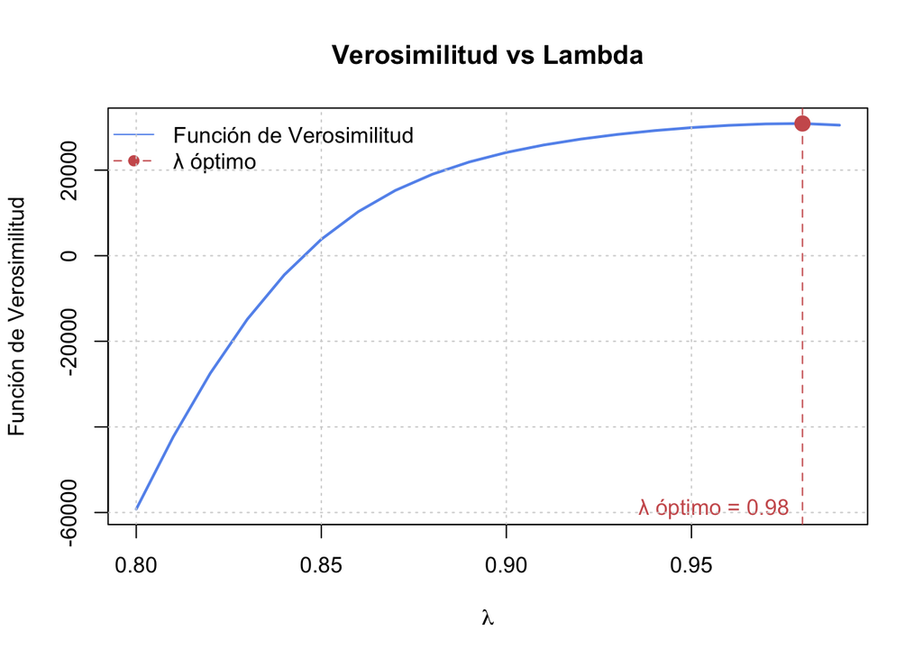

```r
# Gráfica
plot(resultados_df$lambda, resultados_df$verosimilitud,
     type = "l", lwd = 2, col = "cornflowerblue",
     xlab = expression(lambda),
     ylab = "Función de Verosimilitud",
     main = "Verosimilitud vs Lambda")

points(Loptimo, resultados_df$verosimilitud[resultados_df$lambda == Loptimo],
       pch = 19, col = "indianred", cex = 1.5)

abline(v = Loptimo, lty = 2, col = "indianred")

text(Loptimo, min(resultados_df$verosimilitud),
     labels = paste("λ óptimo =", round(Loptimo, 3)),
     pos = 2, col = "indianred")

legend("topleft", legend = c("Función de Verosimilitud", "λ óptimo"),
       col = c("cornflowerblue", "indianred"), lty = c(1, 2), pch = c(NA, 19), bty = "n")

grid()
```

En la gráfica podemos ver como la función de verosimilitud va creciendo y vemos que llega a su máximo en $\lambda = 0.98$ haciendolo el lambda optimo para el modelo de EWMA.

## Modelo EWMA de GCC

$$\sigma^2_t = (1 - 0.98) r_{t-1}^2 + 0.98 \sigma^2_{t-1}$$
Como podemos ver en nuestro modelo de EWMA para GCC, tenemos un lambda de 0.98 al tener un lambda tan alto nos indica que este modelo esta dandole más peso a los datos antiguos que a los recientes y lo hace menos sensible a los cambios actuales en el mercado.

# Modelo ARIMA o ARMA del rendimiento de GCC

```r
ARIMA <- auto.arima(rt)
summary(ARIMA)
```

```
## Series: rt
## ARIMA(1,0,0) with zero mean
##
## Coefficients:
##           ar1
##       -0.2534
## s.e.   0.0143
##
## sigma^2 = 0.0004161:  log likelihood = 11372.76
## AIC=-22741.52   AICc=-22741.52   BIC=-22728.65
##
## Training set error measures:
##                        ME       RMSE       MAE MPE MAPE      MASE         ACF1
## Training set 0.0003500679 0.02039715 0.0112009 NaN  Inf 0.6449354 -0.002922475
```

## Residuos

```r
residuos <- residuals(ARIMA)
```

# ARCH/GARCH

## Prueba de efectos ARCH-GARCH

$$Ho:\text{No hay efectos
ARCH-GARCH}$$
$$Ha:\text{Si hay
efectos ARCH-GARCH}$$

```r
ArchTest <- function (x, lags=20, demean = FALSE)
{
  # Capture name of x for documentation in the output
  xName <- deparse(substitute(x))
  #
  x <- as.vector(x)
  if(demean) x <- scale(x, center = TRUE, scale = FALSE)
  #
  lags <- lags + 1
  mat <- embed(x^2, lags)
  arch.lm <- summary(lm(mat[, 1] ~ mat[, -1]))
  STATISTIC <- arch.lm$r.squared * length(resid(arch.lm))
  names(STATISTIC) <- "Chi-squared"
  PARAMETER <- lags - 1
  names(PARAMETER) <- "df"
  PVAL <- 1 - pchisq(STATISTIC, df = PARAMETER)
  METHOD <- "ARCH LM-test;  Null hypothesis:  no ARCH effects"
  result <- list(statistic = STATISTIC, parameter = PARAMETER,
                 p.value = PVAL, method = METHOD, data.name =
                   xName)
  class(result) <- "htest"
  return(result)
}

ArchTest(rt)
```

```
##
##  ARCH LM-test; Null hypothesis: no ARCH effects
##
## data:  rt
## Chi-squared = 638.68, df = 20, p-value < 2.2e-16
```

Al momento de hacer la prueba obtenemos un p-value el cual es bastante cercano a cero, lo cuál nos dice que al hacer menor a 0.05, se rechaza Ho, por lo tanto si hay efectos GARCH y ARCH para el modelo.

## Modelos ARCH-GARCH

### GARCH(1,1)

```r
GARCH11 <- garchFit(formula=~garch(1,1), data=na.omit(residuos), cond.dist="norm", trace= FALSE)
summary(GARCH11)
```

```
##
## Title:
##  GARCH Modelling
##
## Call:
##  garchFit(formula = ~garch(1, 1), data = na.omit(residuos), cond.dist = "norm",
##     trace = FALSE)
##
## Mean and Variance Equation:
##  data ~ garch(1, 1)
## <environment: 0x120de9040>
##  [data = na.omit(residuos)]
##
## Conditional Distribution:
##  norm
##
## Coefficient(s):
##         mu       omega      alpha1       beta1
## 1.2015e-04  1.9488e-05  6.8752e-02  8.8173e-01
##
## Std. Errors:
##  based on Hessian
##
## Error Analysis:
##         Estimate  Std. Error  t value Pr(>|t|)
## mu     1.202e-04   2.530e-04    0.475    0.635
## omega  1.949e-05   4.270e-06    4.564 5.01e-06 ***
## alpha1 6.875e-02   1.075e-02    6.395 1.60e-10 ***
## beta1  8.817e-01   2.075e-02   42.491  < 2e-16 ***
## ---
## Signif. codes:  0 '***' 0.001 '**' 0.01 '*' 0.05 '.' 0.1 ' ' 1
##
## Log Likelihood:
##  11952.3    normalized:  2.599457
##
## Description:
##  Fri Apr 25 13:38:58 2025 by user:
##
##
## Standardised Residuals Tests:
##                                    Statistic      p-Value
##  Jarque-Bera Test   R    Chi^2  4.578858e+05 0.0000000000
##  Shapiro-Wilk Test  R    W      7.977810e-01 0.0000000000
##  Ljung-Box Test     R    Q(10)  3.260054e+01 0.0003178357
##  Ljung-Box Test     R    Q(15)  3.672205e+01 0.0013892964
##  Ljung-Box Test     R    Q(20)  4.099618e+01 0.0037294437
##  Ljung-Box Test     R^2  Q(10)  2.197616e+00 0.9945888720
##  Ljung-Box Test     R^2  Q(15)  2.338585e+00 0.9999172835
##  Ljung-Box Test     R^2  Q(20)  2.746653e+00 0.9999981000
##  LM Arch Test       R    TR^2   2.215488e+00 0.9989970687
##
## Information Criterion Statistics:
##       AIC       BIC       SIC      HQIC
## -5.197174 -5.191577 -5.197175 -5.195204
```

### GARCH(1,2)

```r
GARCH12 <- garchFit(formula=~garch(1,2), data=na.omit(residuos), cond.dist="norm", trace= FALSE)
summary(GARCH12)
```

```
##
## Title:
##  GARCH Modelling
##
## Call:
##  garchFit(formula = ~garch(1, 2), data = na.omit(residuos), cond.dist = "norm",
##     trace = FALSE)
##
## Mean and Variance Equation:
##  data ~ garch(1, 2)
## <environment: 0x130447e08>
##  [data = na.omit(residuos)]
##
## Conditional Distribution:
##  norm
##
## Coefficient(s):
##         mu       omega      alpha1       beta1       beta2
## 1.1071e-04  2.4275e-05  8.7097e-02  5.5867e-01  2.9226e-01
##
## Std. Errors:
##  based on Hessian
##
## Error Analysis:
##         Estimate  Std. Error  t value Pr(>|t|)
## mu     1.107e-04   2.521e-04    0.439    0.661
## omega  2.428e-05   4.834e-06    5.021 5.13e-07 ***
## alpha1 8.710e-02   1.282e-02    6.795 1.09e-11 ***
## beta1  5.587e-01   7.833e-02    7.132 9.87e-13 ***
## beta2  2.923e-01   7.052e-02    4.144 3.41e-05 ***
## ---
## Signif. codes:  0 '***' 0.001 '**' 0.01 '*' 0.05 '.' 0.1 ' ' 1
##
## Log Likelihood:
##  11959.34    normalized:  2.600987
##
## Description:
##  Fri Apr 25 13:38:58 2025 by user:
##
##
## Standardised Residuals Tests:
##                                    Statistic      p-Value
##  Jarque-Bera Test   R    Chi^2  4.701137e+05 0.0000000000
##  Shapiro-Wilk Test  R    W      7.974124e-01 0.0000000000
##  Ljung-Box Test     R    Q(10)  3.310548e+01 0.0002614872
##  Ljung-Box Test     R    Q(15)  3.728411e+01 0.0011500039
##  Ljung-Box Test     R    Q(20)  4.163334e+01 0.0030863265
##  Ljung-Box Test     R^2  Q(10)  2.203935e+00 0.9945246464
##  Ljung-Box Test     R^2  Q(15)  2.359141e+00 0.9999124569
##  Ljung-Box Test     R^2  Q(20)  2.758178e+00 0.9999980290
##  LM Arch Test       R    TR^2   2.235162e+00 0.9989511184
##
## Information Criterion Statistics:
##       AIC       BIC       SIC      HQIC
## -5.199799 -5.192803 -5.199801 -5.197337
```

### GARCH(2,1)

```r
GARCH21 <- garchFit(formula=~garch(2,1), data=na.omit(residuos), cond.dist="norm", trace= FALSE)
summary(GARCH21)
```

```
##
## Title:
##  GARCH Modelling
##
## Call:
##  garchFit(formula = ~garch(2, 1), data = na.omit(residuos), cond.dist = "norm",
##     trace = FALSE)
##
## Mean and Variance Equation:
##  data ~ garch(2, 1)
## <environment: 0x120d8f938>
##  [data = na.omit(residuos)]
##
## Conditional Distribution:
##  norm
##
## Coefficient(s):
##         mu       omega      alpha1      alpha2       beta1
## 1.2089e-04  1.9435e-05  6.8563e-02  1.0000e-08  8.8204e-01
##
## Std. Errors:
##  based on Hessian
##
## Error Analysis:
##         Estimate  Std. Error  t value Pr(>|t|)
## mu     1.209e-04   2.375e-04    0.509    0.611
## omega  1.944e-05         NaN      NaN      NaN
## alpha1 6.856e-02   9.755e-03    7.028 2.09e-12 ***
## alpha2 1.000e-08         NaN      NaN      NaN
## beta1  8.820e-01         NaN      NaN      NaN
## ---
## Signif. codes:  0 '***' 0.001 '**' 0.01 '*' 0.05 '.' 0.1 ' ' 1
##
## Log Likelihood:
##  11951.92    normalized:  2.599374
##
## Description:
##  Fri Apr 25 13:38:58 2025 by user:
##
##
## Standardised Residuals Tests:
##                                    Statistic      p-Value
##  Jarque-Bera Test   R    Chi^2  4.576932e+05 0.0000000000
##  Shapiro-Wilk Test  R    W      7.978274e-01 0.0000000000
##  Ljung-Box Test     R    Q(10)  3.261783e+01 0.0003157231
##  Ljung-Box Test     R    Q(15)  3.673702e+01 0.0013823417
##  Ljung-Box Test     R    Q(20)  4.101100e+01 0.0037131327
##  Ljung-Box Test     R^2  Q(10)  2.204811e+00 0.9945157088
##  Ljung-Box Test     R^2  Q(15)  2.346086e+00 0.9999155481
##  Ljung-Box Test     R^2  Q(20)  2.754012e+00 0.9999980549
##  LM Arch Test       R    TR^2   2.222350e+00 0.9989812209
##
## Information Criterion Statistics:
##       AIC       BIC       SIC      HQIC
## -5.196572 -5.189576 -5.196575 -5.194110
```

### GARCH(2,2)

```r
GARCH22 <- garchFit(formula=~garch(2,2), data=na.omit(residuos), cond.dist="norm", trace= FALSE)
summary(GARCH22)
```

```
##
## Title:
##  GARCH Modelling
##
## Call:
##  garchFit(formula = ~garch(2, 2), data = na.omit(residuos), cond.dist = "norm",
##     trace = FALSE)
##
## Mean and Variance Equation:
##  data ~ garch(2, 2)
## <environment: 0x130347eb0>
##  [data = na.omit(residuos)]
##
## Conditional Distribution:
##  norm
##
## Coefficient(s):
##         mu       omega      alpha1      alpha2       beta1       beta2
## 1.1071e-04  2.4275e-05  8.7097e-02  1.0000e-08  5.5867e-01  2.9226e-01
##
## Std. Errors:
##  based on Hessian
##
## Error Analysis:
##         Estimate  Std. Error  t value Pr(>|t|)
## mu     1.107e-04   2.516e-04    0.440     0.66
## omega  2.428e-05   1.627e-06   14.922  < 2e-16 ***
## alpha1 8.710e-02   1.280e-02    6.805 1.01e-11 ***
## alpha2 1.000e-08         NaN      NaN      NaN
## beta1  5.587e-01         NaN      NaN      NaN
## beta2  2.923e-01         NaN      NaN      NaN
## ---
## Signif. codes:  0 '***' 0.001 '**' 0.01 '*' 0.05 '.' 0.1 ' ' 1
##
## Log Likelihood:
##  11959.34    normalized:  2.600987
##
## Description:
##  Fri Apr 25 13:38:58 2025 by user:
##
##
## Standardised Residuals Tests:
##                                    Statistic      p-Value
##  Jarque-Bera Test   R    Chi^2  4.701135e+05 0.0000000000
##  Shapiro-Wilk Test  R    W      7.974124e-01 0.0000000000
##  Ljung-Box Test     R    Q(10)  3.310547e+01 0.0002614884
##  Ljung-Box Test     R    Q(15)  3.728410e+01 0.0011500078
##  Ljung-Box Test     R    Q(20)  4.163333e+01 0.0030863348
##  Ljung-Box Test     R^2  Q(10)  2.203933e+00 0.9945246655
##  Ljung-Box Test     R^2  Q(15)  2.359139e+00 0.9999124574
##  Ljung-Box Test     R^2  Q(20)  2.758176e+00 0.9999980290
##  LM Arch Test       R    TR^2   2.235160e+00 0.9989511226
##
## Information Criterion Statistics:
##       AIC       BIC       SIC      HQIC
## -5.199364 -5.190969 -5.199368 -5.196409
```

## Elección del modelo

### Comparación de modelos

[output not shown]

En este caso se elige el modelo GARCH(1,2) ya que comparando las verosimilitudes de los modelos vemos que el GARCH(1,2) y GARCH(2,2) son los mas altos pero el (1,2) tiene 4 parametros siendo los 4 significativos, mientras que el (2,2) tiene 5 parametros pero solo 2 de ellos son significativos es por eso que se elige el modelo GARCH(1,2)

# Comparación de la predicción de los modelos

## Tabla comparativa de las predicciones de los modelos

```r
#-------------------------------------------------------------------------------
# Crear tabla de comparativa de las predicciones de los modelos
#
predicciones <- data.frame(
  Fecha = index(rend_2)[index(rend_2) >= as.Date("2025-03-11") &
                        index(rend_2) <= as.Date("2025-04-25")],
  Varianza_Real_GCC = as.numeric(rend_2[index(rend_2) >= as.Date("2025-03-11") &
                               index(rend_2) <= as.Date("2025-04-25")])
)


#-------------------------------------------------------------------------------
# Predicciones de la media móvil de 5 días
#
indices_completos <- index(rend_2)
valores_completos <- as.numeric(rend_2)

predicciones$`Promedio Movil M=5` <- sapply(1:nrow(predicciones), function(i) {
  pos_actual <- which(indices_completos == predicciones$Fecha[i])

  posiciones <- (pos_actual-5):(pos_actual-1)

  if(all(posiciones >= 1)) {
    mean(valores_completos[posiciones], na.rm = TRUE)
  } else {
    NA
  }
})


#-------------------------------------------------------------------------------
# Predicciones del modelo EWMA
#
lambda <- 0.98

# Función que calcula varianza hasta el indice deseado
varianza_hasta_indice <- function(serie, indice) {
  if (indice < 1 | indice > length(serie)) {
    stop("Índice fuera de rango")
  }

  (sd(serie[1:indice], na.rm = TRUE))^2
}

# Estimaciones para cada fecha
predicciones$`EWMA (0.98)` <- sapply(1:nrow(predicciones), function(i) {
  pos_actual <- which(indices_completos == predicciones$Fecha[i])

  if (pos_actual > 1) {
    var_est <- (1 - lambda) * valores_completos[pos_actual - 1] + lambda * varianza_hasta_indice(rt, pos_actual - 2)
  } else {
    NA
  }
})


#-------------------------------------------------------------------------------
# Predicciones del GARCH(1,2)
#
# Especificación del modelo GARCH(1,2)
spec_garch12 <- ugarchspec(
  variance.model = list(model = "sGARCH", garchOrder = c(1,2)),
  mean.model = list(armaOrder = c(1,0)),
  distribution.model = "std"
)

fecha_inicio_pred <- as.Date("2025-03-11")
indice_corte <- which(index(rt) == fecha_inicio_pred - 1)

# Función para ajuste y pronóstico rolling
predicciones$`GARCH(1,2)` <- sapply(1:nrow(predicciones), function(i) {
  fecha_actual <- predicciones$Fecha[i]
  indice_actual <- which(index(rt) == fecha_actual)

  # Datos hasta el día anterior al actual
  datos_entrenamiento <- residuos[1:(indice_actual-1)]

  # Ajustar modelo con datos actualizados (refit)
  fit_actual <- ugarchfit(
    spec = spec_garch12,
    data = datos_entrenamiento
  )

  # Pronosticar varianza para el día actual
  pred <- ugarchforecast(fit_actual, n.ahead = 1)
  sigma(pred)[1]^2
})

knitr::kable(predicciones, caption = "Comparación de valores reales y predicciones", digits = 6)
```

Comparación de valores reales y predicciones

| Fecha | Varianza_Real_GCC | Promedio Movil M=5 | EWMA (0.98) | GARCH(1,2) |
| --- | --- | --- | --- | --- |
| 2025-03-11 | 0.000035 | 0.000252 | 0.000436 | 0.000324 |
| 2025-03-12 | 0.000065 | 0.000257 | 0.000432 | 0.000176 |
| 2025-03-13 | 0.000423 | 0.000175 | 0.000432 | 0.000120 |
| 2025-03-14 | 0.000380 | 0.000259 | 0.000440 | 0.000282 |
| 2025-03-18 | 0.000107 | 0.000232 | 0.000439 | 0.000304 |
| 2025-03-19 | 0.000003 | 0.000202 | 0.000433 | 0.000228 |
| 2025-03-20 | 0.000000 | 0.000196 | 0.000431 | 0.000114 |
| 2025-03-21 | 0.000301 | 0.000183 | 0.000431 | 0.000061 |
| 2025-03-24 | 0.000167 | 0.000158 | 0.000437 | 0.000184 |
| 2025-03-25 | 0.000015 | 0.000116 | 0.000434 | 0.000155 |
| 2025-03-26 | 0.000004 | 0.000097 | 0.000431 | 0.000091 |
| 2025-03-27 | 0.000013 | 0.000097 | 0.000431 | 0.000049 |
| 2025-03-28 | 0.000458 | 0.000100 | 0.000431 | 0.000029 |
| 2025-03-31 | 0.000499 | 0.000131 | 0.000440 | 0.000243 |
| 2025-04-01 | 0.001282 | 0.000198 | 0.000440 | 0.000407 |
| 2025-04-02 | 0.000135 | 0.000451 | 0.000456 | 0.000820 |
| 2025-04-03 | 0.000002 | 0.000477 | 0.000433 | 0.000503 |
| 2025-04-04 | 0.014143 | 0.000475 | 0.000431 | 0.000255 |
| 2025-04-07 | 0.000077 | 0.003212 | 0.000713 | 0.007443 |
| 2025-04-08 | 0.001228 | 0.003128 | 0.000435 | 0.003352 |
| 2025-04-09 | 0.004434 | 0.003117 | 0.000458 | 0.002198 |
| 2025-04-10 | 0.004387 | 0.003977 | 0.000522 | 0.003180 |
| 2025-04-11 | 0.000451 | 0.004854 | 0.000522 | 0.003328 |
| 2025-04-14 | 0.000235 | 0.002115 | 0.000444 | 0.001703 |
| 2025-04-15 | 0.003501 | 0.002147 | 0.000440 | 0.001078 |
| 2025-04-16 | 0.000720 | 0.002601 | 0.000505 | 0.002323 |
| 2025-04-21 | 0.000480 | 0.001859 | 0.000450 | 0.001332 |
| 2025-04-22 | 0.000362 | 0.001077 | 0.000445 | 0.000819 |
| 2025-04-23 | 0.000048 | 0.001060 | 0.000443 | 0.000559 |
| 2025-04-24 | 0.000229 | 0.001022 | 0.000437 | 0.000280 |

La tabla anterior compara la varianza real de los rendimientos al cuadrado de GCC con las estimaciones generadas por tres modelos: media móvil (M=5), EWMA (λ = 0.98) y GARCH(1,2). Se observa una tendencia creciente en la varianza a partir del 1 de abril, lo que sugiere un aumento en la volatilidad del activo.

Aunque el modelo EWMA mantiene una estimación relativamente estable, tanto la media móvil como GARCH capturan mejor las fluctuaciones abruptas, especialmente en fechas como el 4 de abril, donde la varianza real se dispara. Sin embargo, el modelo GARCH(1,2) destaca por ajustarse más a los movimientos de la varianza real, mostrando una mayor capacidad para adaptarse a los cambios repentinos en la volatilidad del mercado.

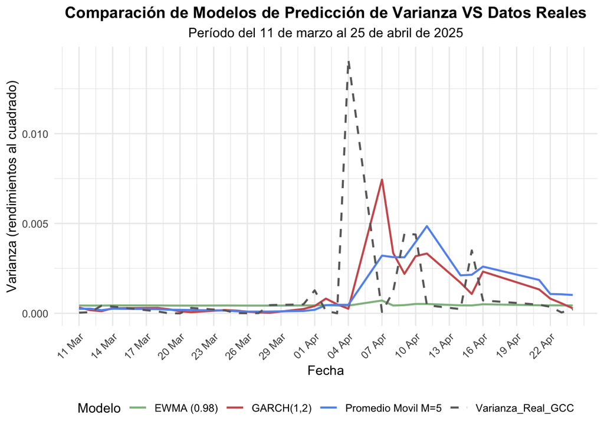

```r
predicciones_largo <- predicciones |>
  pivot_longer(cols = -Fecha,
               names_to = "Modelo",
               values_to = "Varianza")

ggplot(predicciones_largo, aes(x = Fecha, y = Varianza, color = Modelo, linetype = Modelo)) +
  geom_line(linewidth = 0.8) +
  scale_color_manual(values = c(
    "Varianza_Real_GCC" = "dimgray",
    "Promedio Movil M=5" = "cornflowerblue",
    "EWMA (0.98)" = "darkseagreen",
    "GARCH(1,2)" = "indianred"
  )) +
  scale_linetype_manual(values = c(
    "Varianza_Real_GCC" = "dashed",
    "Promedio Movil M=5" = "solid",
    "EWMA (0.98)" = "solid",
    "GARCH(1,2)" = "solid"
  )) +
  labs(
    title = "Comparación de Modelos de Predicción de Varianza VS Datos Reales",
    subtitle = "Período del 11 de marzo al 25 de abril de 2025",
    x = "Fecha",
    y = "Varianza (rendimientos al cuadrado)",
    color = "Modelo",
    linetype = "Modelo"
  ) +
  theme_minimal() +
  theme(
    legend.position = "bottom",
    plot.title = element_text(hjust = 0.5, face = "bold"),
    plot.subtitle = element_text(hjust = 0.5),
    axis.text.x = element_text(angle = 45, hjust = 1)
  ) +
  scale_x_date(
    breaks = seq(min(predicciones$Fecha), max(predicciones$Fecha), by = "3 days"),
    labels = date_format("%d %b")
  ) +
  guides(color = guide_legend(nrow = 1), linetype = guide_legend(nrow = 1))
```

La gráfica muestra la comparación de la varianza real de los rendimientos al cuadrado de GCC con las estimaciones generadas por los modelos de media móvil (M=5), EWMA (λ = 0.98) y GARCH(1,2). La línea punteada representa la varianza real, mientras que las líneas continuas representan las estimaciones de los modelos.Se puede observar que la varianza real llega a un punto más alto que el resto, mienstras que GARCH(1,2) es el que más se acerca a la varianza real, seguido de la media movil y por último el EWMA.

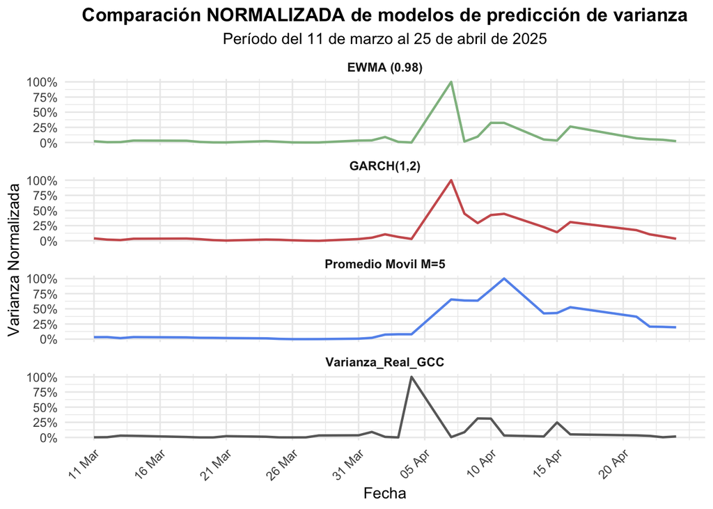

```r
# Normalizar cada serie entre 0 y 1
predicciones_normalizado <- predicciones_largo %>%
  group_by(Modelo) %>%
  mutate(Varianza_norm = (Varianza - min(Varianza)) / (max(Varianza) - min(Varianza))) %>%
  ungroup()

# Gráfico con datos normalizados
ggplot(predicciones_normalizado, aes(x = Fecha, y = Varianza_norm, color = Modelo)) +
  geom_line(linewidth = 0.8) +
  facet_wrap(~Modelo, ncol = 1, scales = "fixed") +
  scale_color_manual(values = c(
    "Varianza_Real_GCC" = "dimgray",
    "Promedio Movil M=5" = "cornflowerblue",
    "EWMA (0.98)" = "darkseagreen",
    "GARCH(1,2)" = "indianred"
  )) +
  labs(
    title = "Comparación NORMALIZADA de modelos de predicción de varianza",
    subtitle = "Período del 11 de marzo al 25 de abril de 2025",
    x = "Fecha",
    y = "Varianza Normalizada"
  ) +
  theme_minimal() +
  theme(
    legend.position = "none",
    plot.title = element_text(hjust = 0.5, face = "bold"),
    plot.subtitle = element_text(hjust = 0.5),
    axis.text.x = element_text(angle = 45, hjust = 1),
    strip.text = element_text(face = "bold")
  ) +
  scale_x_date(
    breaks = seq(min(predicciones$Fecha), max(predicciones$Fecha), by = "5 days"),
    labels = date_format("%d %b")
  ) +
  scale_y_continuous(labels = scales::percent_format(accuracy = 1))
```

De igual manera, se presenta la comparación de los modelos de predicción de varianza, pero esta vez normalizando cada serie entre 0 y 1. Esto permite observar cómo se comportan los modelos en relación a su propio rango de valores, facilitando la comparación visual entre ellos. De esta manera EWMA y GARCH(1,2) se comportan de manera similar, mientras que la media movil tiene un comportamiento diferente al de los otros dos modelos, ya que refleja los cambios abruptos en la varianza de manera más tardada. La varianza real se comporta de manera similar a la de GARCH(1,2) pero con un rango más amplio.

# Conclusión

En conclusión, esta entrega del proyecto permitió identificar patrones de riesgo en el activo GCC utilizando diferentes métodos de estimación de volatilidad. Analizando los rendimientos logarítmicos diarios, se encontró que una media móvil de 5 días ofrecía una mejor capacidad de seguimiento de la varianza diaria, reflejando de manera más precisa los resultados del corto plazo.

Contar con una buena estimación de la volatilidad es fundamental, ya que permite tener más información del riesgo, anticipar escenarios de inestabilidad y mejorar la toma de decisiones en activos, así mismo, los modelos dinámicos como los utilizados en este análisis son herramientas clave para construir estrategias financieras más sólidas frente a la incertidumbre del mercado.